# Tyler Grimes

Assistant Professor of Statistics  
[Department of Mathematics and Statistics](https://www.unf.edu/coas/math-stat/index.html)  
[University of North Florida](https://www.unf.edu/)

[Google Scholar](https://scholar.google.com/citations?user=ROPfgIEAAAAJ&hl) [LinkedIn](https://www.linkedin.com/in/tylerlgrimes/) [Github](https://github.com/tgrimes) CV

Hey, I’m Tyler, a biostatistician working in genomics and clinical research. My research is focused on the development of statistical methodology for high-dimensional -omics data to study the biological drivers of autoimmune diseases. This involves problems related to clinical predictive modeling, statistical inferences on association networks, multi-omics integration, and the development of statistical software packages that implement these methods.

On this site, you can find various notes containing random experiments and code snippets used for testing ideas, along with talks and papers from past research projects.

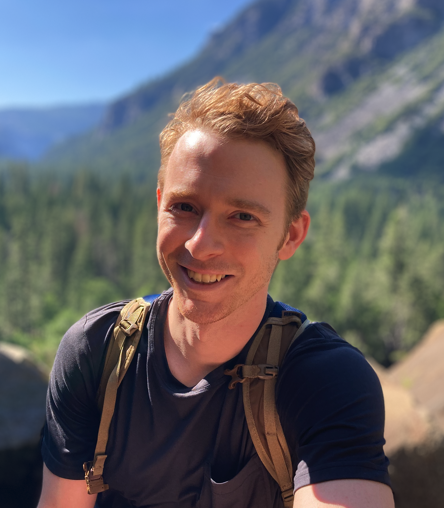

## Grimes Lab

Our group is working on understanding the biological drivers of [systemic lupus erythematosus (SLE)](https://www.lupus.org/resources/what-is-systemic-lupus-erythematosus-sle). Lupus is the one of the most common autoimmune diseases and can affect multiple organ systems. It’s a heterogeneous disease–meaning it presents differently from one person to the next. This makes it hard to diagnose, and there’s no single treatment plan that works for everyone. The cause of SLE is unknown, but it’s believed to develop in response to a combination of environmental and internal, biological factors. We are interested in understanding the genetic and biological drivers of SLE. The statistical methods we develop are aimed at finding predictive biomarkers that can be used for prognosis or to guide treatment decisions.

## Statistical research

Our areas of statistical research include topics in:

- Statistical methods for -omics data
- Graphical models and differential network analysis
- Predictive modeling
- High-dimensional data analysis
- Statistical computing

Past research has focused on RNA-seq gene expression data, developing methods in the areas of graphical modeling, prediction, and survival analysis. Typical research questions included: How can gene expression be used to improve prediction of survival in cancer patients? Do gene regulatory networks differ in high-risk vs. low-risk patients, and what do those differences tell us about the underlying disease?

Simulation studies are an indispensable tool for modern research. Aside from allowing us to assess model performance, creating a simulation forces us to think deeply about the data generating process and the context of the problem at hand–this is a process that has often lead me to new insights.

[figure not shown]